# Homework-Compilation

SA24005089

2024-12-08

# Homework Compilation

This vignette compiles the content of ten assignments.

## Assignment 1

### Example1

画一个100个随机点形成的散点图

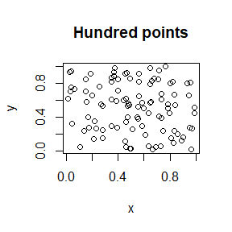

```r
s<-matrix(runif(10*20),nrow=100,ncol=2)
plot(s,main="Hundred points",xlab="x",ylab="y")
```

### Example2

在0到100的范围中选取10个数，绘制每个数的条形图

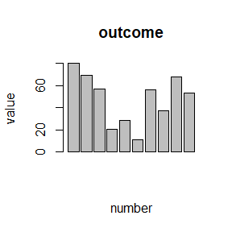

```r
s<-sample(0:100,size=10,replace=FALSE)
barplot(s,main='outcome',ylab='value',xlab='number')
```

### Example3

计算1000次每次100步的非负随机游走(计1步为0.1格)，计算到达每一步的频数

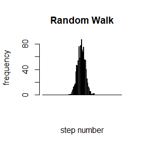

```r
nub<-matrix(0,101,1)
for(i in 1:1000){
s<-sample(c(0,1),size=100,replace=TRUE)
s1<-sum(s)
nub[s1]<-nub[s1]+1
}
barplot(t(nub),main='Random Walk',xlab="step number",ylab="frequency")
```

## Assignment 2

### Exercise 3.4

Caption: use $\frac{e^{-\frac{x}{\sigma}}}{\sigma}$ as $g(x)$, where $c=2.5$, $G(x)=1-e^{-\frac{x}{\sigma}}$.By using inverse sampling method:$G^{-1}(x)=-\sigma\ln(1-x)$, random number of $G(x)$ can be generated.

$\sigma=1$

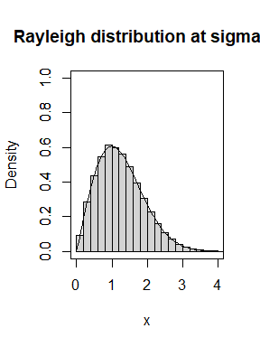

```r
n <- 1e5;j<-k<-0;y <- numeric(n);
sig<-1;
while (k < n) {
  u <- runif(1)
  j <- j + 1
  x <- -sig*log(1-runif(1),base=exp(1)) #random variate from g(.)
  if  ((x/(sig)^2*exp(-x^2/(2*sig^2)))/(2.5*exp(-x/sig)/sig)> u) {#c=2.5
    #we accept x
    k <- k + 1
    y[k] <- x
  }
}
hist(y,breaks=20,main="Rayleigh distribution at sigma=1",xlim=c(0,4),ylim=c(0,1),freq=F,xlab="x")
par(new=TRUE)
curve((x/sig^2*exp(-x^2/2/sig^2)),0,4,xlab="",ylab="",xaxt="n",ylim=c(0,1))
```

$\sigma=0.5$

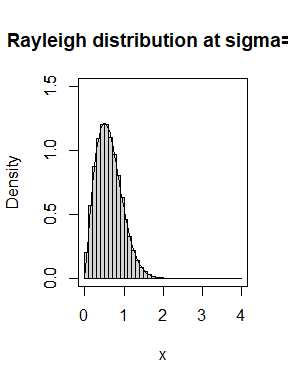

```r
n <- 1e5;j<-k<-0;y <- numeric(n);
sig<-0.5;
while (k < n) {
  u <- runif(1)
  j <- j + 1
  x <- -sig*log(1-runif(1),base=exp(1)) #random variate from g(.)
  if  ((x/(sig)^2*exp(-x^2/(2*sig^2)))/(2.5*exp(-x/sig)/sig)> u) {#c=2.5
    #we accept x
    k <- k + 1
    y[k] <- x
  }
}
hist(y,breaks=20,main="Rayleigh distribution at sigma=0.5",xlim=c(0,4),ylim=c(0,1.5),freq=F,xlab="x")
par(new=TRUE)
curve((x/sig^2*exp(-x^2/2/sig^2)),0,4,xlab="",ylab="",xaxt="n",ylim=c(0,1.5))
```

$\sigma=2$

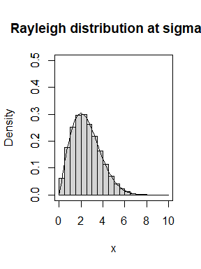

```r
n <- 1e5;j<-k<-0;y <- numeric(n);
sig<-2;
while (k < n) {
  u <- runif(1)
  j <- j + 1
  x <- -sig*log(1-runif(1),base=exp(1)) #random variate from g(.)
  if  ((x/(sig)^2*exp(-x^2/(2*sig^2)))/(2.5*exp(-x/sig)/sig)> u) {#c=2.5
    #we accept x
    k <- k + 1
    y[k] <- x
  }
}
hist(y,breaks=20,main="Rayleigh distribution at sigma=2",xlim=c(0,10),ylim=c(0,0.5),freq=F,xlab="x")
par(new=TRUE)
curve((x/sig^2*exp(-x^2/2/sig^2)),0,10,xlab="",ylab="",xaxt="n",ylim=c(0,0.5))
```

### Exercise 3.11

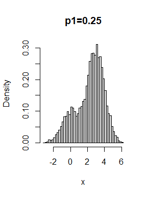

```r
n<-1e4;p1<-0.25;j<-0;x<-numeric(n)
while(j<n){
  u<-runif(1)
  j<-j+1
  if(u<p1){
    x[j]<-rnorm(1,0,1)
  }
  else{
    x[j]<-rnorm(1,3,1)
  }
}
hist(x,freq=F,main="p1=0.25",breaks=50)
```

当p1=0.5时会出现双峰

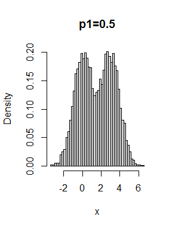

```r
n<-1e4;p1<-0.5;j<-0;x<-numeric(n)
while(j<n){
  u<-runif(1)
  j<-j+1
  if(u<p1){
    x[j]<-rnorm(1,0,1)
  }
  else{
    x[j]<-rnorm(1,3,1)
  }
}
hist(x,freq=F,main="p1=0.5",breaks=50)
```

### Exercise 3.20

考虑到泊松分布$E(N(t))=\lambda t$,则在$t=10$时有$E[N(10)-N(0)]=10\lambda$

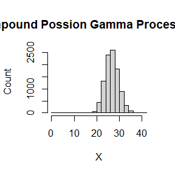

```r
    n <- 1e4; r <- 4; beta <- 3;j<-0;y<-numeric(n);
while(j<n){
    #lambda <- rgamma(1, r, beta)#假设lambda依然由gamma分布给出
  lambda<-2
    x1 <- floor(10*lambda);
    #y1 <- sum(rnbinom(x1,size=r,prob=beta/(1+beta)));
    y1<-sum(rgamma(x1,r,beta))
    y[j]<-y1;
    j=j+1;

}
   ave=mean(y)
   avar=var(y)
   tave=2*10*4/3
   tvar=2*10*4/3/3
    hist(y,main="Compound Possion Gamma Process at t=10",xlab="X",ylab="Count")
```

根据直方图可以得出$E=26.65$,$var=8.63$。理论计算显示$E=26.67$,$var=8.89$，相差不大！

## Assignment 3

### Exercise 5.4

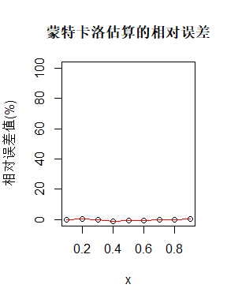

```r
m<-1e4;j<-1;mcbeta<-numeric(9);fc<-numeric(9);
for (x in seq(from=0.1, to=0.9, length.out=9)){
  y<-runif(m,min=0,max=x)
  theta.hat<-mean(y^2*(1-y)^2)
  mcbeta[j]<-theta.hat*x*gamma(6)/gamma(3)/gamma(3)
  fc[j]<-(pbeta(x,3,3)-mcbeta[j])/pbeta(x,3,3)
  j<-j+1
}
plot(seq(from=0.1, to=0.9, length.out=9),fc*100,xlim=c(0.1,0.9),ylim=c(0,100),main="蒙特卡洛估算的相对误差",xlab="x",ylab="相对误差值(%)")
lines(seq(from=0.1, to=0.9, length.out=9),fc*100,xlim=c(0.1,0.9),ylim=c(0,100),col="red")
```

可以看出，误差很小。

\

### Exercise 5.9

使用之前建立过的Rayleigh函数进行估算

```r
n <- 1e3;j<-k<-0;y1 <- numeric(n);y2 <- numeric(n);y3<-numeric(n);y4<-numeric(n)
sig<-1;
u0<-runif(5*n)
while (k < n) {
  u <- u0[j+1]
  j <- j + 1
  x <- -sig*log(1-runif(1),base=exp(1)) #random variate from g(.)
  if  ((x/(sig)^2*exp(-x^2/(2*sig^2)))/(2.5*exp(-x/sig)/sig)> u) {#c=2.5
    #we accept x
    k <- k + 1
    y1[k] <- x
  }
}
j<-k<-0;
while (k < n) {
  u <- u0[j+1]
  u <- 1-u
  j <- j + 1
  x <- -sig*log(1-runif(1),base=exp(1)) #random variate from g(.)
  if  ((x/(sig)^2*exp(-x^2/(2*sig^2)))/(2.5*exp(-x/sig)/sig)> u) {#c=2.5
    #we accept x
    k <- k + 1
    y2[k] <- x
  }
}
var1=var((y1+y2)/2)
j<-k<-0;
n<-500;
while (k < n) {
  u <- runif(1)
  j <- j + 1
  x <- -sig*log(1-runif(1),base=exp(1)) #random variate from g(.)
  if  ((x/(sig)^2*exp(-x^2/(2*sig^2)))/(2.5*exp(-x/sig)/sig)> u) {#c=2.5
    #we accept x
    k <- k + 1
    y3[k] <- x
  }
}
j<-k<-0;
while (k < n) {
  u <- runif(1)
  j <- j + 1
  x <- -sig*log(1-runif(1),base=exp(1)) #random variate from g(.)
  if  ((x/(sig)^2*exp(-x^2/(2*sig^2)))/(2.5*exp(-x/sig)/sig)> u) {#c=2.5
    #we accept x
    k <- k + 1
    y4[k] <- x
  }
}
var2=var((y3+y4)/2)
```

通过上述计算得到在计算点数总数为1000点时，$\frac{X+X'}{2}$的方差为0.2076,而$\frac{X_1+X_2}{2}$的方差为0.5076，可以得到Antithetic方法确实让方差降低了很多。 \

### Exercise 5.13

如下图，黑线为函数$\frac{x^2}{\sqrt{2\pi}}e^{\frac{-x^2}{2}}$列出两个函数:$g1(x)=\frac{1}{cos(1)+1}sin(x),x\to(1,\pi)$（图中红线）和$g2(x)=e^{1-x},x\to(1,+\infty)$（图中绿线）

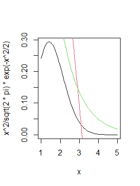

```r
curve(x^2/sqrt(2*pi)*exp(-x^2/2),1,5,col=1)
curve(1/(1+cos(1))*sin(x),1,5,,col=2,add=TRUE)
curve(exp(1-x),1,5,,col=3,add=TRUE)
```

对它们分别进行重要性采样

```r
n<-1e5;k<-1;y1<-y2<-numeric(n)
while(k<=n){
  u<- runif(1)
  y1[k]<- acos(cos(1)-(cos(1)+1)*u);
  if(y1[k]>=1){
  x<- y1[k];
  y2[k]<-(x^2/sqrt(2*pi)*exp(-x^2/2))/(1/(1+cos(1))*sin(x))
  k=k+1
  }
  }
mean(y2)
```

```
## [1] 0.3908627
```

```r
var(y2)
```

```
## [1] 0.007382134
```

```r
n<-1e5;k<-1;y1<-y3<-numeric(n)
while(k<=n){
  u<- runif(1)
  y1[k]<- 1-log(u,base=exp(1));
  if(y1[k]>=1){
  x<- y1[k];
  y3[k]<-(x^2/sqrt(2*pi)*exp(-x^2/2))/(exp(1-x))
  k=k+1
  }
  }
mean(y3)
```

```
## [1] 0.4002509
```

```r
var(y3)
```

```
## [1] 0.02487725
```

```r
n<-1e4;u<-runif(n,0,10)
x<-(u>1)*u
y4<-mean(x^2/sqrt(2*pi)*exp(-x^2/2))
```

### Monte Carlo Experiment

对快速排序法进行编程：

```r
library(tictoc)
fastsort <- function(x){
    if(length(x)<=1)return(x)
    x0 <- x[1]
    loc <- 1
    low <- 1
    n <- length(x)
    high <- n
    while(low != high){

        if(loc == low){
            if(x[high] < x[loc]){
                tmp <- x[high]
                x[high] <- x[loc]
                x[loc] <- tmp
                low = low+1
                loc = high
            }else{
                    high = high - 1
                }
            }else{
                if(x[low] > x[loc]){
                    tmp <- x[low]
                    x[low] <- x[loc]
                    x[loc] <- tmp
                    high = high -1
                    loc = low
                }else{
                    low = low+1
                }
           }
        }
    L = c()
    R = c()
    if(low>1) L = x[1:(low-1)]
    if(low<length(x)) R = x[(low+1):n]
    return(c(fastsort(L),x[low],fastsort(R)))
}
for(n in c(1e4,2e4,4e4,6e4,8e4)){

  tic()
  for(i in seq(1,10)){
    m<-sample(n,replace=FALSE)
    fastsort(m)
  }
  toc()
}
```

```
## 0.25 sec elapsed
## 0.52 sec elapsed
## 1.03 sec elapsed
## 1.58 sec elapsed
## 2.18 sec elapsed
```

对所得数据进行回归,如下图，其中散点为数据点，黑线为$xlog(x)$的回归曲线，可以看到时间和复杂度的拟合程度很一致：

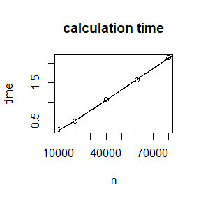

```r
timq<-c(0.28,0.5,1.07,1.56,2.14);
plot(c(1e4,2e4,4e4,6e4,8e4),c(0.28,0.5,1.07,1.56,2.14),main="calculation time",xlab="n",ylab="time")
x<-c(1e4,2e4,4e4,6e4,8e4);
y<-c(0.28,0.5,1.07,1.56,2.14);
regmodel<-lm(formula=y~x*log(x))
x<-seq(from=1e4,to=1e5)
y1<-predict(regmodel,newdata=list(x=seq(
  from=1e4,to=1e5)))
matlines(x,y1, lwd=1.5)
```